# IDG-DREAM Round 2 Bayes Factor Analysis

06 May, 2019

Round 2 of the IDG-DREAM Challenge gave participants two opportunities to predict 394 Kd values between 25 compounds and 207 kinases. There are two subchallenges in this round that participants can win via:

Sub-challenge 1: The top-performing teams will be selected based on the bootstrapped Spearman correlation of the predictions to the test dataset. Teams that have a Bayes Factor of less than 3 are tied. The tiebreaking metric to select the top performer will be the submission with the highest average AUC score.

Sub-challenge 2: The top-performing teams will be selected based on the bootstrapped RMSE of the predictions to the test dataset. Teams that have a Bayes Factor of less than 3 are tied. The tiebreaking metric to select the top performer will be the submission with the highest average AUC score.

In addition, participants/teams needed to submit a Dockerized model, writeup, and methods survey to qualified. Participants that could not fulfill this criteria were disqualified.

Here, we are only looking at qualified results (when considering who submitted a Docker container).

[output not shown]

```
Welcome, Robert Allaway!
```

## OFFICIAL RESULTS

Here, we’ve analyzed only the submissions that met the ‘letter of the law’ eg. they submitted a survey, write-up, and Docker container.

### SC1 - SPEARMAN

For SC1: Spearman, the top participant on the leaderboard and Bayes calculation reference is team Q.E.D.

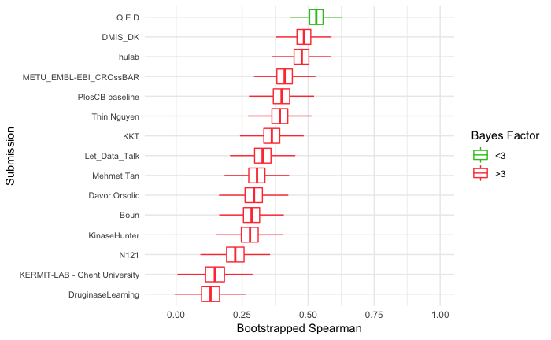

### SC2 - RMSE

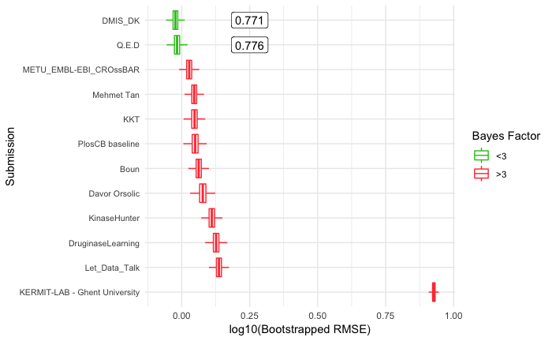